# Project - Thera Bank

Juan Esteban Venegas

### 1. Project Objectives

The objective is to build a model for the marketing department of the Thera Bank to identify the potential customers who have a higher probability of purchasing a loan. This will increase the success ratio while at the same time reduce the cost of the campaign.

### 2. Exploratory Data Analysis – Step by step approach

#### 2.1 Environment Set up and Data Import

##### 2.1.1 Call necessary Packages and Invoke Libraries

```r
pacman::p_load(ggplot2, data.table, scales, corrplot, car, psych, broom, readxl, glmnet, NbClust, cluster, caret, factoextra, rpart.plot, rpart)
```

##### 2.1.2 Set up working Directory

```r
setwd('C:/Users/Juan Esteban Venegas/Desktop/Machine Learning Learning/Greatlearning/Greatlearning_projects/Project_4_Thera_Bank')
getwd()
```

```
[1] "C:/Users/Juan Esteban Venegas/Desktop/Machine Learning Learning/Greatlearning/Greatlearning_projects/Project_4_Thera_Bank"
```

##### 2.1.3 Import and Read the Dataset

Dataset consists of a sheet with information and the data base. The sheet with information contains a brief description on each variable which is shown below:

```r
print(ReadMe)
```

```
                      Variable                                                                 Description
 1:                         ID                                                                 Customer ID
 2:                        Age                                                     Customer's age in years
 3:                 Experience                                            Years of professional experience
 4:                     Income                                        Annual income of the customer ($000)
 5:                    ZIPCode                                                      Home Address ZIP code.
 6:                     Family                                                 Family size of the customer
 7:                      CCAvg                              Avg. spending on credit cards per month ($000)
 8:                  Education        Education Level. 1: Undergrad; 2: Graduate; 3: Advanced/Professional
 9:                   Mortgage                                      Value of house mortgage if any. ($000)
10:              Personal Loan    Did this customer accept the personal loan offered in the last campaign?
11:         Securities Account                  Does the customer have a securities account with the bank?
12:                 CD Account Does the customer have a certificate of deposit (CD) account with the bank?
13:                     Online                          Does the customer use internet banking facilities?
14:                 CreditCard                     Does the customer use a credit card issued by the bank?
15: Note: Data is hypothetical                                                                        <NA>
```

Some variables need to be transformed from numeric to factor. In addition to this, additional validations must be made to define future data preparation steps.

```r
str(Thera_Bank)
```

```
Classes ‘data.table’ and 'data.frame':  5000 obs. of  14 variables:
 $ ID                 : num  1 2 3 4 5 6 7 8 9 10 ...
 $ Age_in_years       : num  25 45 39 35 35 37 53 50 35 34 ...
 $ Experience_in_years: num  1 19 15 9 8 13 27 24 10 9 ...
 $ Income_in_Kmonth   : num  49 34 11 100 45 29 72 22 81 180 ...
 $ ZIP_Code           : num  91107 90089 94720 94112 91330 ...
 $ Family_members     : num  4 3 1 1 4 4 2 1 3 1 ...
 $ CCAvg              : num  1.6 1.5 1 2.7 1 0.4 1.5 0.3 0.6 8.9 ...
 $ Education          : num  1 1 1 2 2 2 2 3 2 3 ...
 $ Mortgage           : num  0 0 0 0 0 155 0 0 104 0 ...
 $ Personal_Loan      : num  0 0 0 0 0 0 0 0 0 1 ...
 $ Securities_Account : num  1 1 0 0 0 0 0 0 0 0 ...
 $ CD_Account         : num  0 0 0 0 0 0 0 0 0 0 ...
 $ Online             : num  0 0 0 0 0 1 1 0 1 0 ...
 $ CreditCard         : num  0 0 0 0 1 0 0 1 0 0 ...
 - attr(*, ".internal.selfref")=<externalptr>
```

```r
summary(Thera_Bank)
```

```
       ID        Age_in_years   Experience_in_years Income_in_Kmonth    ZIP_Code     Family_members
 Min.   :   1   Min.   :23.00   Min.   :-3.0        Min.   :  8.00   Min.   : 9307   Min.   :1.000
 1st Qu.:1251   1st Qu.:35.00   1st Qu.:10.0        1st Qu.: 39.00   1st Qu.:91911   1st Qu.:1.000
 Median :2500   Median :45.00   Median :20.0        Median : 64.00   Median :93437   Median :2.000
 Mean   :2500   Mean   :45.34   Mean   :20.1        Mean   : 73.77   Mean   :93153   Mean   :2.397
 3rd Qu.:3750   3rd Qu.:55.00   3rd Qu.:30.0        3rd Qu.: 98.00   3rd Qu.:94608   3rd Qu.:3.000
 Max.   :5000   Max.   :67.00   Max.   :43.0        Max.   :224.00   Max.   :96651   Max.   :4.000
                                                                                     NA's   :18
     CCAvg          Education        Mortgage     Personal_Loan   Securities_Account   CD_Account
 Min.   : 0.000   Min.   :1.000   Min.   :  0.0   Min.   :0.000   Min.   :0.0000     Min.   :0.0000
 1st Qu.: 0.700   1st Qu.:1.000   1st Qu.:  0.0   1st Qu.:0.000   1st Qu.:0.0000     1st Qu.:0.0000
 Median : 1.500   Median :2.000   Median :  0.0   Median :0.000   Median :0.0000     Median :0.0000
 Mean   : 1.938   Mean   :1.881   Mean   : 56.5   Mean   :0.096   Mean   :0.1044     Mean   :0.0604
 3rd Qu.: 2.500   3rd Qu.:3.000   3rd Qu.:101.0   3rd Qu.:0.000   3rd Qu.:0.0000     3rd Qu.:0.0000
 Max.   :10.000   Max.   :3.000   Max.   :635.0   Max.   :1.000   Max.   :1.0000     Max.   :1.0000

     Online         CreditCard
 Min.   :0.0000   Min.   :0.000
 1st Qu.:0.0000   1st Qu.:0.000
 Median :1.0000   Median :0.000
 Mean   :0.5968   Mean   :0.294
 3rd Qu.:1.0000   3rd Qu.:1.000
 Max.   :1.0000   Max.   :1.000
```

Variable Family_members has null values. Variable Experience_in_years has negative values. These two issues need to be addressed before creating the model.

##### 2.1.4 Data Transformation

- Variables to factor:

```r
Thera_Bank[,c('Education', 'Personal_Loan', 'Securities_Account', 'CD_Account', 'Online', 'CreditCard')] <- lapply(Thera_Bank[,c('Education', 'Personal_Loan', 'Securities_Account', 'CD_Account', 'Online', 'CreditCard')] , factor)
```

- Missing values: Before deciding what to do with missing values it is useful to view the distribution of numeric variables and if they have outliers.

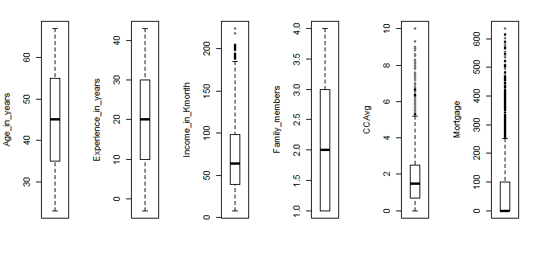

```r
numeric_variables <- names(which(sapply(Thera_Bank,is.numeric) & !(names(Thera_Bank) %in% c('ID', 'ZIP_Code'))))
par(mfrow = c(1,length(numeric_variables)))
outliers_list <- list()
  for(i in 1:length(numeric_variables)){
    plot <- boxplot(Thera_Bank[,numeric_variables[i], with = FALSE], ylab = numeric_variables[i])
    outliers_list[[numeric_variables[i]]] <- Thera_Bank[eval(parse(text = numeric_variables[i])) %in% plot$out]
    outliers_list[[numeric_variables[i]]]$outlier <- numeric_variables[i]
    }
```

```r
table(Thera_Bank$Family_members)
```

```
   1    2    3    4
1464 1292 1009 1217
```

Because of this, instead of removing the ID’s with missing values it will be easier to input them using the median.

```r
Thera_Bank[, Family_members := ifelse(is.na(Family_members), median(Thera_Bank$Family_members, na.rm = TRUE), Family_members)]
sum(is.na(Thera_Bank))
```

```
[1] 0
```

- Negative Experience: Beofre deciding what to do with negative Experience_in_years values it is important to understand this variable better.

```r
cor_matrix <- cor(Thera_Bank[,numeric_variables, with = FALSE])
cor_matrix
```

```
                    Age_in_years Experience_in_years Income_in_Kmonth Family_members       CCAvg    Mortgage
Age_in_years          1.00000000          0.99421486      -0.05526862    -0.04542979 -0.05201218 -0.01253859
Experience_in_years   0.99421486          1.00000000      -0.04657418    -0.05158364 -0.05007651 -0.01058155
Income_in_Kmonth     -0.05526862         -0.04657418       1.00000000    -0.15736366  0.64598367  0.20680623
Family_members       -0.04542979         -0.05158364      -0.15736366     1.00000000 -0.11031420 -0.02022110
CCAvg                -0.05201218         -0.05007651       0.64598367    -0.11031420  1.00000000  0.10990472
Mortgage             -0.01253859         -0.01058155       0.20680623    -0.02022110  0.10990472  1.00000000
```

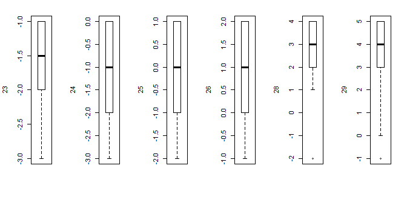

```r
neg_exp_age <- unique(Thera_Bank[Experience_in_years <0, .(Age_in_years)][order(Age_in_years)])
par(mfrow = c(1,nrow(neg_exp_age)))
  for(i in 1:nrow(neg_exp_age)){
    plot <- boxplot(Thera_Bank[Age_in_years == as.numeric(neg_exp_age[i,1])]$Experience_in_years, ylab = neg_exp_age[i,1])
    }
```

Age and Experience have a very high positive correlation so it is important to see how age behaves with negative experience. Negative experience values have ages

| Age_in_years |
| --- |
| 23 |
| 24 |
| 25 |
| 26 |
| 28 |
| 29 |

values.

Observations with age <= 25 have negative median or 0 for experience which could mean that some of these people are studying and these negative years could be interpreted as years left to graduate. However, there is no information to deduce this so people under 25 with negative experience will be assign a 0 for their experience.

People with experience bellow 0 and age >= 26 will be assigned a median value for experience.

```r
median_experience <- Thera_Bank[,.(med_exp = median(Experience_in_years, na.rm = TRUE)), by = .(Age_in_years)]
Thera_Bank <- median_experience[Thera_Bank, on = c('Age_in_years')]
Thera_Bank <- Thera_Bank[, Experience_in_years := ifelse(Experience_in_years < 0 & Age_in_years <= 25, 0, ifelse(Experience_in_years <0, med_exp, Experience_in_years))][, med_exp := NULL]
```

- One hot encoding: One hot encoding will be performed to be able to easily manage categorical variables.

```r
str(Thera_Bank_ohe)
```

```
'data.frame':   5000 obs. of  21 variables:
 $ Age_in_years        : num  25 45 39 35 35 37 53 50 35 34 ...
 $ ID                  : num  1 2 3 4 5 6 7 8 9 10 ...
 $ Experience_in_years : num  1 19 15 9 8 13 27 24 10 9 ...
 $ Income_in_Kmonth    : num  49 34 11 100 45 29 72 22 81 180 ...
 $ ZIP_Code            : Factor w/ 467 levels "9307","90005",..: 84 35 368 299 97 161 116 268 35 236 ...
 $ Family_members      : num  4 3 1 1 4 4 2 1 3 1 ...
 $ CCAvg               : num  1.6 1.5 1 2.7 1 0.4 1.5 0.3 0.6 8.9 ...
 $ Education.1         : num  1 1 1 0 0 0 0 0 0 0 ...
 $ Education.2         : num  0 0 0 1 1 1 1 0 1 0 ...
 $ Education.3         : num  0 0 0 0 0 0 0 1 0 1 ...
 $ Mortgage            : num  0 0 0 0 0 155 0 0 104 0 ...
 $ Personal_Loan.0     : num  1 1 1 1 1 1 1 1 1 0 ...
 $ Personal_Loan.1     : num  0 0 0 0 0 0 0 0 0 1 ...
 $ Securities_Account.0: num  0 0 1 1 1 1 1 1 1 1 ...
 $ Securities_Account.1: num  1 1 0 0 0 0 0 0 0 0 ...
 $ CD_Account.0        : num  1 1 1 1 1 1 1 1 1 1 ...
 $ CD_Account.1        : num  0 0 0 0 0 0 0 0 0 0 ...
 $ Online.0            : num  1 1 1 1 1 0 0 1 0 1 ...
 $ Online.1            : num  0 0 0 0 0 1 1 0 1 0 ...
 $ CreditCard.0        : num  1 1 1 1 0 1 1 0 1 1 ...
 $ CreditCard.1        : num  0 0 0 0 1 0 0 1 0 0 ...
```

#### 2.3 Univariate Analysis

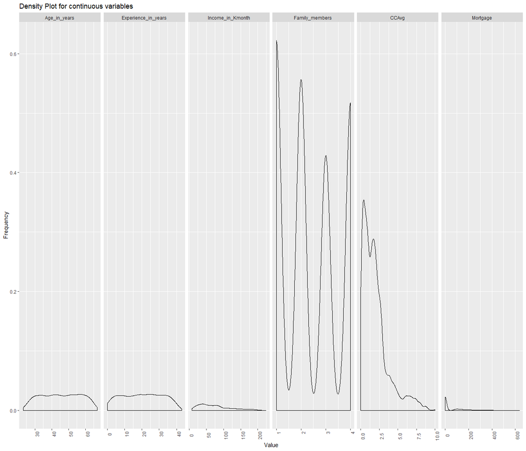

```r
ggplot(melt(Thera_Bank[,c(numeric_variables,'ID'), with = FALSE][], id.vars = 'ID', variable.name = 'Variable', value.name = 'Value'), aes(x = Value)) + geom_density() + facet_grid(.~Variable, scales = 'free') + labs(title = 'Density Plot for continuous variables', x = 'Value', y = 'Frequency') + theme(axis.text.x = element_text(angle = 90))
```

Age and experience seem to have similar distributions with the sample spread evenly. Income, CCAvg and Mortgage seem to be right skewed.

#### 2.4 Bi-Variate Analysis

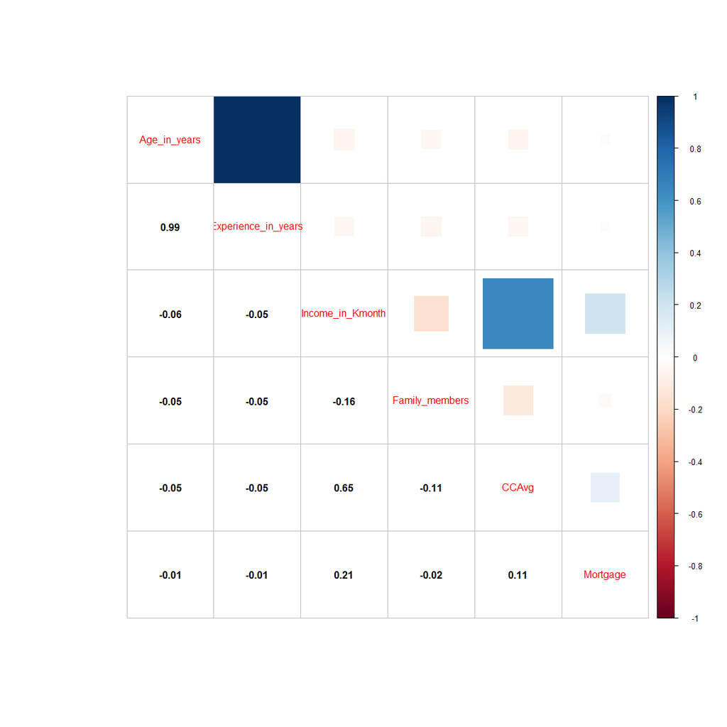

When looking at correlations between numeric variables, we can see that the strongest correlation between independent variables is Age and Experience. There is also a positive correlation between income and average spending on credit cards per month.

#### 2.5 EFA

For factor analysis, we first need to define the number of factors to use. One way to do this is by using Psych package:

```
Parallel analysis suggests that the number of factors =  2  and the number of components =  NA
```

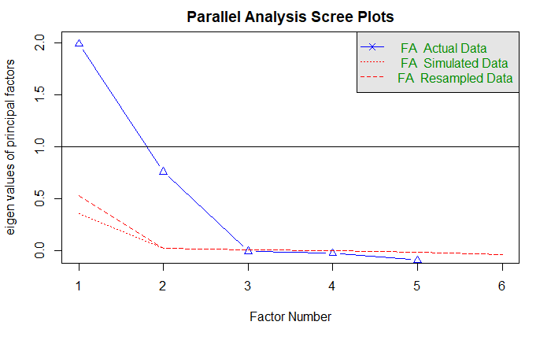

```r
Parallel <- fa.parallel(Thera_Bank_fa, fm = 'minres', fa = 'fa')
```

Point inflection where the gap between simulated data and actual data tends to be minimum happens on 2 factors.

We run the factor analysis with 2 factors and use oblimin as rotations since we believe that there is correlation in the factors.

```r
FA <- fa(Thera_Bank_fa,nfactors = 2,rotate = "oblimin",fm="minres")
print(FA)
```

```
Factor Analysis using method =  minres
Call: fa(r = Thera_Bank_fa, nfactors = 2, rotate = "oblimin",
    fm = "minres")
Standardized loadings (pattern matrix) based upon correlation matrix
                      MR1   MR2    h2     u2 com
Age_in_years         1.00  0.00 0.993 0.0074 1.0
Experience_in_years  1.00  0.00 0.995 0.0046 1.0
Income_in_Kmonth     0.00  1.00 0.998 0.0020 1.0
Family_members      -0.06 -0.16 0.029 0.9710 1.2
CCAvg               -0.02  0.64 0.416 0.5839 1.0
Mortgage             0.00  0.19 0.038 0.9620 1.0

                       MR1  MR2
SS loadings           1.99 1.48
Proportion Var        0.33 0.25
Cumulative Var        0.33 0.58
Proportion Explained  0.57 0.43
Cumulative Proportion 0.57 1.00

 With factor correlations of
      MR1   MR2
MR1  1.00 -0.06
MR2 -0.06  1.00

Mean item complexity =  1
Test of the hypothesis that 2 factors are sufficient.

The degrees of freedom for the null model are  15  and the objective function was  5.09 with Chi Square of  25441.31
The degrees of freedom for the model are 4  and the objective function was  0.01

The root mean square of the residuals (RMSR) is  0.01
The df corrected root mean square of the residuals is  0.01

The harmonic number of observations is  5000 with the empirical chi square  6.05  with prob <  0.2
The total number of observations was  5000  with Likelihood Chi Square =  30.75  with prob <  3.4e-06

Tucker Lewis Index of factoring reliability =  0.996
RMSEA index =  0.037  and the 90 % confidence intervals are  0.025 0.049
BIC =  -3.32
Fit based upon off diagonal values = 1
Measures of factor score adequacy
                                                   MR1 MR2
Correlation of (regression) scores with factors   1.00   1
Multiple R square of scores with factors          1.00   1
Minimum correlation of possible factor scores     0.99   1
```

Now we need to consider the loadings more than 0.5 and not loading on more than one factor:

```r
print(FA$loadings,cutoff = 0.5)
```

```
Loadings:
                    MR1    MR2
Age_in_years         0.996
Experience_in_years  0.998
Income_in_Kmonth            0.999
Family_members
CCAvg                       0.644
Mortgage

                 MR1   MR2
SS loadings    1.992 1.478
Proportion Var 0.332 0.246
Cumulative Var 0.332 0.578
```

From the above, we can see that Family_members and Mortgage have become insignificant and that there is no double loading.

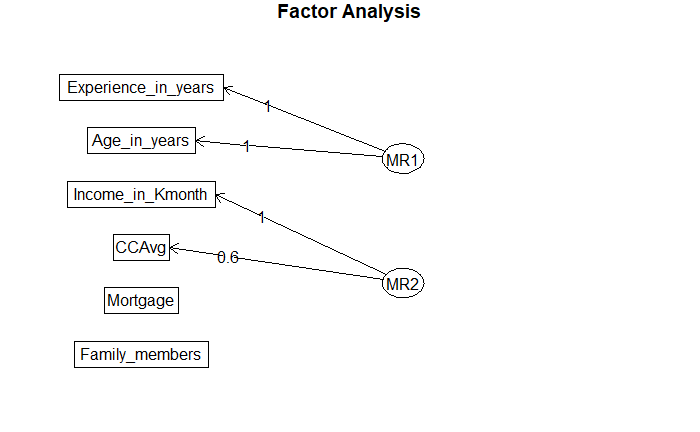

Looking at the 2 factors created, we will proceed to add them to the data and rename them

```r
head(Thera_Bank_ohe,2)
```

```
   Personal_Loan Age_in_years Experience_in_years Income_in_Kmonth Family_members CCAvg Education.1 Education.2
1:             0           25                   1               49              4   1.6           1           0
2:             0           45                  19               34              3   1.5           1           0
   Education.3 Mortgage Securities_Account.0 Securities_Account.1 CD_Account.0 CD_Account.1 Online.0 Online.1
1:           0        0                    0                    1            1            0        1        0
2:           0        0                    0                    1            1            0        1        0
   CreditCard.0 CreditCard.1         Exp  P_Finance         Exp  P_Finance         Exp  P_Finance
1:            1            0 -1.70888580 -0.5390392 -1.70888580 -0.5390392 -1.70888580 -0.5390392
2:            1            0 -0.07063983 -0.8548730 -0.07063983 -0.8548730 -0.07063983 -0.8548730
```

### 3. Clustering

#### 3.1 Kmeans Clustering

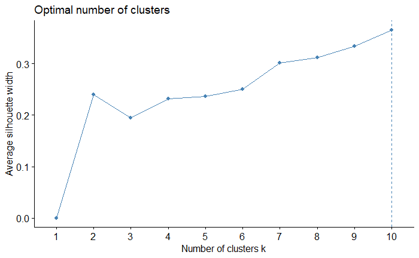

```r
set.seed(1000)
Thera_Bank_scaled <- scale(Thera_Bank_ohe[,c(7,8,9,11,12,13,14,15,16,17,18,19,20)])
fviz_nbclust(Thera_Bank_scaled, kmeans, method='silhouette')
```

Kmeans Clustering works with numeric data because it uses distance between observations to determine if they are similar or not. Because of this, the first step is to select numeric data from the table and scale it. We then run different centers to determine what the best number of clusters is for this data set. function above is used to run the silhouette method to determine the ideal number of clusters.

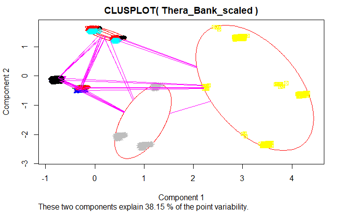

We assign the clusters to the data base and observe that the biggest cluster has 750 customers and the smallest has 302.

```r
Thera_Bank_ohe$cluster <- Kmeans_clusters$cluster
table(Thera_Bank_ohe$cluster)
```

```
  1   2   3   4   5   6   7   8   9  10
520 342 562 542 323 551 302 375 733 750
```

```r
table(Thera_Bank_ohe$cluster, Thera_Bank_ohe$Personal_Loan)
```

```
       0   1
  1  509  11
  2  321  21
  3  492  70
  4  471  71
  5  305  18
  6  526  25
  7  162 140
  8  366   9
  9  642  91
  10 726  24
```

#### 4 CART

Before running CART we will first split the dataset into training and testing sets.

```r
set.seed(1000)
Thera_Bank_model <- Thera_Bank_ohe[,c(1,5,7,19:21) ]
train_sel <- sample(x = 1:nrow(Thera_Bank_ohe), size = round(nrow(Thera_Bank)*.7))
train <- Thera_Bank_model[train_sel]
test <- Thera_Bank_model[!train_sel]
```

We then proceed to run an initial CART model:

```r
set.seed(1000)
tree <- rpart(formula = Personal_Loan ~ ., data = train, method = "class", cp=0, minbucket=3)
tree
```

```
n= 3500

node), split, n, loss, yval, (yprob)
      * denotes terminal node

   1) root 3500 342 0 (0.902285714 0.097714286)
     2) P_Finance< 0.8691607 2812  61 0 (0.978307255 0.021692745)
       4) P_Finance< 0.4134995 2544  18 0 (0.992924528 0.007075472)
         8) P_Finance< 0.1672535 2231   6 0 (0.997310623 0.002689377) *
         9) P_Finance>=0.1672535 313  12 0 (0.961661342 0.038338658)
          18) Exp< 1.711819 310  11 0 (0.964516129 0.035483871)
            36) P_Finance>=0.1686625 307  10 0 (0.967426710 0.032573290)
              72) Exp< 0.2339618 191   3 0 (0.984293194 0.015706806) *
              73) Exp>=0.2339618 116   7 0 (0.939655172 0.060344828)
               146) P_Finance>=0.2013167 93   3 0 (0.967741935 0.032258065) *
               147) P_Finance< 0.2013167 23   4 0 (0.826086957 0.173913043)
                 294) P_Finance< 0.1975817 19   1 0 (0.947368421 0.052631579) *
                 295) P_Finance>=0.1975817 4   1 1 (0.250000000 0.750000000) *
            37) P_Finance< 0.1686625 3   1 0 (0.666666667 0.333333333) *
          19) Exp>=1.711819 3   1 0 (0.666666667 0.333333333) *
       5) P_Finance>=0.4134995 268  43 0 (0.839552239 0.160447761)
        10) Family_members< 2.5 167  16 0 (0.904191617 0.095808383)
          20) Education.1>=0.5 97   3 0 (0.969072165 0.030927835)
            40) Exp< 1.204574 83   1 0 (0.987951807 0.012048193) *
            41) Exp>=1.204574 14   2 0 (0.857142857 0.142857143)
              82) P_Finance>=0.6144106 11   0 0 (1.000000000 0.000000000) *
              83) P_Finance< 0.6144106 3   1 1 (0.333333333 0.666666667) *
          21) Education.1< 0.5 70  13 0 (0.814285714 0.185714286)
            42) P_Finance< 0.6700885 47   5 0 (0.893617021 0.106382979)
              84) Exp< 1.237179 42   2 0 (0.952380952 0.047619048) *
              85) Exp>=1.237179 5   2 1 (0.400000000 0.600000000) *
            43) P_Finance>=0.6700885 23   8 0 (0.652173913 0.347826087)
              86) Family_members< 1.5 12   2 0 (0.833333333 0.166666667) *
              87) Family_members>=1.5 11   5 1 (0.454545455 0.545454545)
               174) cluster>=8.5 3   0 0 (1.000000000 0.000000000) *
               175) cluster< 8.5 8   2 1 (0.250000000 0.750000000) *
        11) Family_members>=2.5 101  27 0 (0.732673267 0.267326733)
          22) cluster< 2.5 16   0 0 (1.000000000 0.000000000) *
          23) cluster>=2.5 85  27 0 (0.682352941 0.317647059)
            46) Exp< -1.50332 8   0 0 (1.000000000 0.000000000) *
```

[output cut: 17 more lines]

```
     3) P_Finance>=0.8691607 688 281 0 (0.591569767 0.408430233)
       6) Education.1>=0.5 443  49 0 (0.889390519 0.110609481)
        12) Family_members< 2.5 394   0 0 (1.000000000 0.000000000) *
        13) Family_members>=2.5 49   0 1 (0.000000000 1.000000000) *
       7) Education.1< 0.5 245  13 1 (0.053061224 0.946938776)
        14) P_Finance< 0.9332386 23  10 0 (0.565217391 0.434782609)
          28) Exp>=1.045461 5   0 0 (1.000000000 0.000000000) *
          29) Exp< 1.045461 18   8 1 (0.444444444 0.555555556)
            58) P_Finance>=0.8763321 15   7 0 (0.533333333 0.466666667)
             116) P_Finance< 0.8912679 6   1 0 (0.833333333 0.166666667) *
             117) P_Finance>=0.8912679 9   3 1 (0.333333333 0.666666667)
               234) Exp< -0.1784576 5   2 0 (0.600000000 0.400000000) *
               235) Exp>=-0.1784576 4   0 1 (0.000000000 1.000000000) *
            59) P_Finance< 0.8763321 3   0 1 (0.000000000 1.000000000) *
        15) P_Finance>=0.9332386 222   0 1 (0.000000000 1.000000000) *
```

[figure not shown]

```r
rpart.plot(tree)
```

With the above tree we then obtain the complexity table to start prunning.

```r
printcp(tree)
```

```
Classification tree:
rpart(formula = Personal_Loan ~ ., data = train, method = "class",
    cp = 0, minbucket = 3)

Variables actually used in tree construction:
[1] cluster        Education.1    Exp            Family_members P_Finance

Root node error: 342/3500 = 0.097714

n= 3500

          CP nsplit rel error  xerror     xstd
1 0.32017544      0   1.00000 1.00000 0.051364
2 0.14327485      2   0.35965 0.36550 0.032102
3 0.00877193      3   0.21637 0.22222 0.025212
4 0.00584795      4   0.20760 0.22807 0.025534
5 0.00334169      7   0.19006 0.21930 0.025050
6 0.00292398     18   0.13743 0.21345 0.024721
7 0.00146199     25   0.11696 0.22515 0.025374
8 0.00097466     27   0.11404 0.23977 0.026166
9 0.00000000     33   0.10819 0.23977 0.026166
```

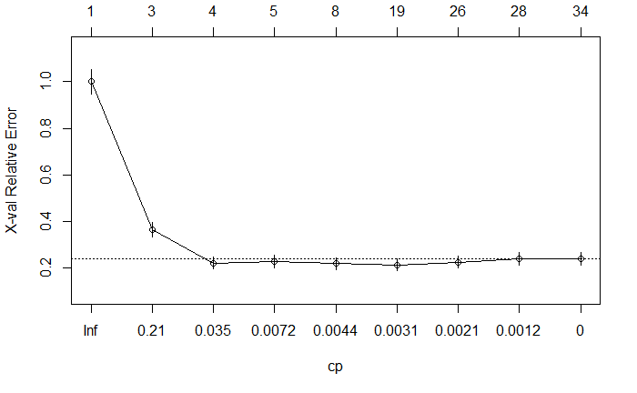

```r
plotcp(tree)
```

```r
ptree = prune(tree, cp= 0.03 ,"CP")
printcp(ptree)
```

```
Classification tree:
rpart(formula = Personal_Loan ~ ., data = train, method = "class",
    cp = 0, minbucket = 3)

Variables actually used in tree construction:
[1] Education.1    Family_members P_Finance

Root node error: 342/3500 = 0.097714

n= 3500

       CP nsplit rel error  xerror     xstd
1 0.32018      0   1.00000 1.00000 0.051364
2 0.14327      2   0.35965 0.36550 0.032102
3 0.03000      3   0.21637 0.22222 0.025212
```

```r
ptree
```

```
n= 3500

node), split, n, loss, yval, (yprob)
      * denotes terminal node

 1) root 3500 342 0 (0.90228571 0.09771429)
   2) P_Finance< 0.8691607 2812  61 0 (0.97830725 0.02169275) *
   3) P_Finance>=0.8691607 688 281 0 (0.59156977 0.40843023)
     6) Education.1>=0.5 443  49 0 (0.88939052 0.11060948)
      12) Family_members< 2.5 394   0 0 (1.00000000 0.00000000) *
      13) Family_members>=2.5 49   0 1 (0.00000000 1.00000000) *
     7) Education.1< 0.5 245  13 1 (0.05306122 0.94693878) *
```

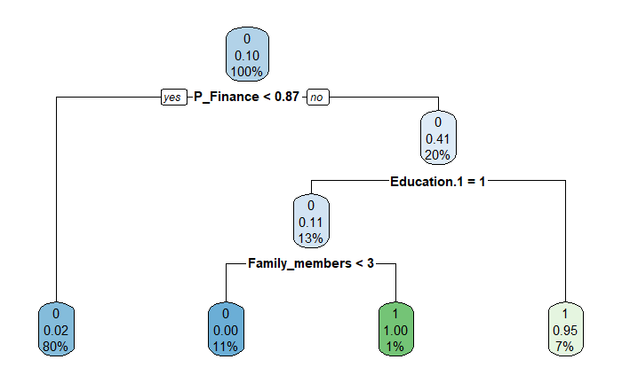

```r
rpart.plot(ptree)
```

The next step is to test the model on train and test data:

```r
train$prediction = predict(ptree, newdata= train, type="class")
tbl <- table(train$Personal_Loan, train$prediction)
print(tbl)
```

```
       0    1
  0 3145   13
  1   61  281
```

```r
print((tbl[1,2]+tbl[2,1])/nrow(test))
```

```
[1] 0.04933333
```

```r
test$prediction = predict(ptree, newdata= test, type="class")
tbl <- table(test$Personal_Loan, test$prediction)
print(tbl)
```

```
       0    1
  0 1359    3
  1   22  116
```

```r
print((tbl[1,2]+tbl[2,1])/nrow(test))
```

```
[1] 0.01666667
```

Test model also seems to yield good results. Out of 138 people in the test dataset who said yes to the loan, the model predicted 116 correctly. The model also did a good job in predicting people who chose not to take the offer, out of 1362 customers who said no, the model was able to predict 1359.

#### 4 Random Forest

The above CART results are encouraging and it means that we are in the right track to be able to identify future customers that will be more likely to accept a loan offer given the past experience with previous campaigns.

To improve the robustness of the model, the next step is to train a random forest model which is similar to creating a model from several independent “tree” models until we have a forest. This way, we make the model stronger by trining it with different iterations of data and prepare it so it behaves better when unseen data is fed into the model.

```r
train$prediction <- NULL
test$prediction <- NULL
set.seed(1000)
Thera_Bank_model <- Thera_Bank_ohe[,c(1,5,7,19:21) ]
train_sel <- sample(x = 1:nrow(Thera_Bank_ohe), size = round(nrow(Thera_Bank)*.7))
train <- Thera_Bank_model[train_sel]
test <- Thera_Bank_model[!train_sel]
set.seed(1000)
rndFor = randomForest(Personal_Loan ~ ., data = train, ntree = round(0.2*nrow(train)), mtry = round(sqrt(length(train)-1)), nodesize = 10,importance=TRUE)
print(rndFor)
```

```
Call:
 randomForest(formula = Personal_Loan ~ ., data = train, ntree = round(0.2 *      nrow(train)), mtry = round(sqrt(length(train) - 1)), nodesize = 10,      importance = TRUE)
               Type of random forest: classification
                     Number of trees: 700
No. of variables tried at each split: 2

        OOB estimate of  error rate: 2.06%
Confusion matrix:
     0   1 class.error
0 3150   8 0.002533249
1   64 278 0.187134503
```

We first start by creating a model with temporary parameters. For ntree we use 20% of the observations in the train dataset and for the mtry we use sqrt of the number of variables.

The below graph shows the evolution of the error rate for out of the bag sampling, error 1 and 0 depending on the number of trees that our model has. According to the graph, there is not a significance reduction in errors after 100 trees so we can stop our model here in order to avoid computational cost.

```r
rndFor$err.rate
```

```
              OOB           0         1
  [1,] 0.03016241 0.015410959 0.1680000
  [2,] 0.03063148 0.010966057 0.2125604
  [3,] 0.02907422 0.008890771 0.2182540
  [4,] 0.03179973 0.010123735 0.2318339
  [5,] 0.03333333 0.010204082 0.2467532
  [6,] 0.03323171 0.011486486 0.2343750
  [7,] 0.02892069 0.009256198 0.2097264
  [8,] 0.02643948 0.007817590 0.1976048
  [9,] 0.02526132 0.007724493 0.1869436
 [10,] 0.02511547 0.007997441 0.1834320
 [11,] 0.02530917 0.007331846 0.1911765
 [12,] 0.02437625 0.006359300 0.1900585
 [13,] 0.02348897 0.006668784 0.1783626
 [14,] 0.02346880 0.006979695 0.1754386
```

[output cut: 320 more lines]

```r
plot(rndFor, main="")
legend("topright", c("OOB", "0", "1"), text.col=1:6, lty=1:3, col=1:3)
```

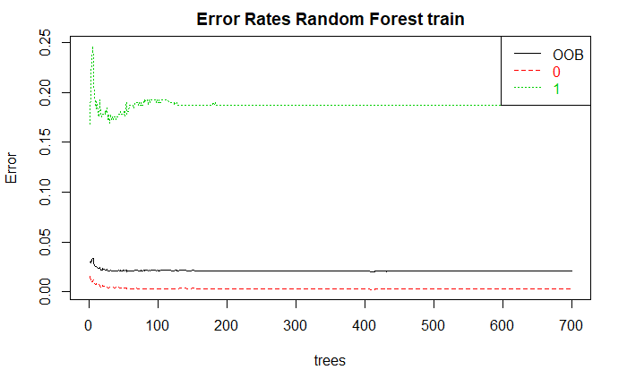

```r
title(main="Error Rates Random Forest train")
```

When listing the importance of the variables in the model, it appears as if P_Finance has the biggest mean decreace in accuracy which makes it more important for the model.

```r
rndFor$importance
```

```
                         0            1 MeanDecreaseAccuracy MeanDecreaseGini
Family_members 0.053018865  0.071360162          0.054819055         64.85698
Education.1    0.060407337  0.135834311          0.067772355         93.16279
Exp            0.002760720 -0.001142193          0.002377141         28.48861
P_Finance      0.131849198  0.584736311          0.176059977        332.48164
cluster        0.004151827  0.034997047          0.007161986         30.68604
```

Next step is to “tune” the Random Forest by trying different m values. We will use 101 trees because of the explanation provided above.

```
mtry = 3  OOB error = 2.03%
Searching left ...
mtry = 2    OOB error = 2.14%
-0.05633803 1e-04
Searching right ...
mtry = 4    OOB error = 1.94%
0.04225352 1e-04
mtry = 5    OOB error = 2.06%
-0.05882353 1e-04
```

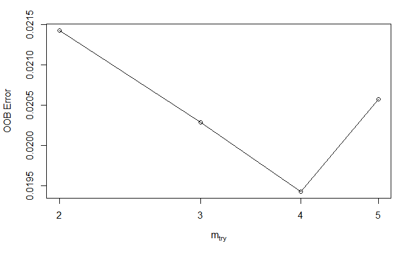

```r
set.seed(1000)
tRndFor = tuneRF(x = train[,!("Personal_Loan")],
              y=train$Personal_Loan,
              mtryStart = 3,
              ntreeTry = 101,
              stepFactor = 1.5,
              improve = 0.0001,
              trace=TRUE,
              plot = TRUE,
              doBest = TRUE,
              nodesize = 10,
              importance=TRUE
)
```

```r
importance(tRndFor)
```

```
                        0           1 MeanDecreaseAccuracy MeanDecreaseGini
Family_members 184.188553  73.1323017           193.154749        94.121234
Education.1    184.675413  98.1980867           205.230254       171.668834
Exp             22.607804   0.3868534            21.728748        28.226507
P_Finance      317.665376 327.4529381           345.935083       270.037463
cluster          5.586097   6.7661110             7.708178         9.334758
```

Model predictions on the training data seem very good with only 39 people marked as not taking the loan that eventually took it.

```r
## Scoring syntax
train$predict.class = predict(tRndFor, train, type="class")
train$prob1 = predict(tRndFor, train, type="prob")[,"1"]
tbl <- table(train$Personal_Loan, train$predict.class)
print(tbl)
```

```
       0    1
  0 3156    2
  1   39  303
```

```r
print((tbl[1,2]+tbl[2,1])/nrow(train))
```

```
[1] 0.01171429
```

```r
## Scoring syntax
test$predict.class = predict(tRndFor, test, type="class")
test$prob1 = predict(tRndFor, test, type="prob")[,"1"]
tbl <- table(test$Personal_Loan, test$predict.class)
print(tbl)
```

```
       0    1
  0 1359    3
  1   21  117
```

```r
print((tbl[1,2]+tbl[2,1])/nrow(test))
```

```
[1] 0.016
```

Test data set also yields good results.

Overall, the model proves to be useful in clearly identifying those customers who will not acquire the loan and it also does a good job in selecting customers who will acquire it.

I would look for two particular customer profiles described below:

```r
## Scoring syntax
cust_1 <- Thera_Bank_ohe[P_Finance >= 0.87 & Education.1 != 1]
summary(cust_1[,.(Income_in_Kmonth, CCAvg)])
```

```
 Income_in_Kmonth     CCAvg
 Min.   :113.0    Min.   : 0.000
 1st Qu.:131.0    1st Qu.: 2.300
 Median :154.0    Median : 3.950
 Mean   :153.4    Mean   : 3.976
 3rd Qu.:178.0    3rd Qu.: 5.670
 Max.   :203.0    Max.   :10.000
```

+cust_1 : Customers with annual income of at least 113,000 and average spending in credit cards per month of aroud 4,000 who have graduate degree or higher.

```r
## Scoring syntax
cust_2 <- Thera_Bank_ohe[P_Finance >= 0.87 & Education.1 == 1 & Family_members >3]
summary(cust_2[,.(Income_in_Kmonth, CCAvg, Education.1, Family_members)])
```

```
 Income_in_Kmonth     CCAvg        Education.1 Family_members
 Min.   :114.0    Min.   :0.200   Min.   :1    Min.   :4
 1st Qu.:130.0    1st Qu.:1.675   1st Qu.:1    1st Qu.:4
 Median :144.5    Median :4.025   Median :1    Median :4
 Mean   :147.1    Mean   :3.603   Mean   :1    Mean   :4
 3rd Qu.:164.0    3rd Qu.:5.400   3rd Qu.:1    3rd Qu.:4
 Max.   :195.0    Max.   :6.900   Max.   :1    Max.   :4
```

Similar to customer 1. The difference is that these customers have an undergraduate degree and families with at least 4 members.